# Second Homework Report

Mobile Data

Parand Alizadeh

2018-02-20 00:15:31

# تمرین سری دوم: تلفن همراه شناسی!

> با استفاده از داده های گوشی های همراه به سوالات زیر پاسخ دهید. برای رسم نمودار از پکیج ggplot2 استفاده کنید.

۱. کدام شرکت بیشترین تعداد گوشی را تولید کرده است؟ نمودار ستونی ۲۰ شرکت برتر بر حسب تعداد گوشی تولید کرده را رسم کنید.

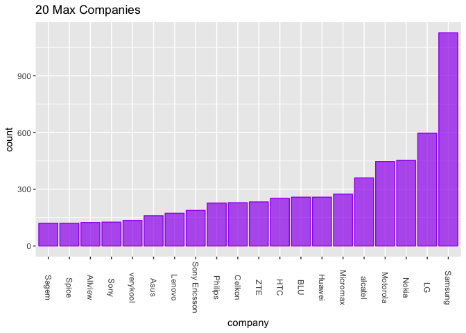

۲. نمودار زمانی طول عرض ضخامت و کیفیت دوربین گوشی ها را بکشید و به نمودار هر یک مدل خطی اضافه کنید.

نمودار زمانی عرض:

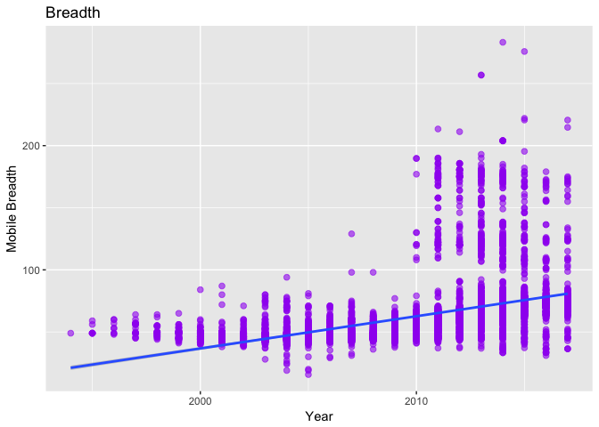

نمودار زمانی میانگین عرض:

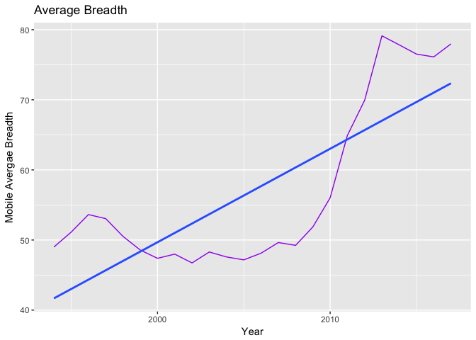

نمودار زمانی طول:

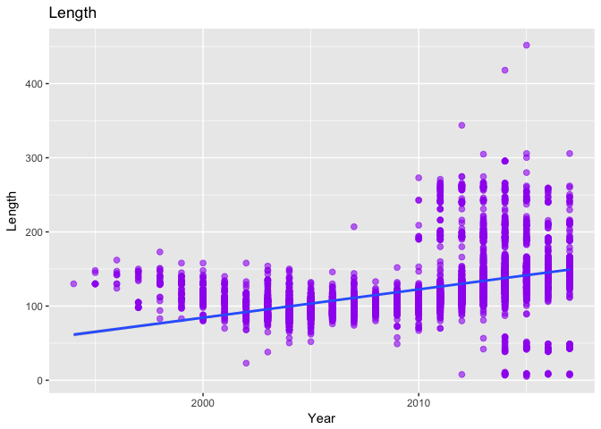

نمودار زمانی میانگین طول:

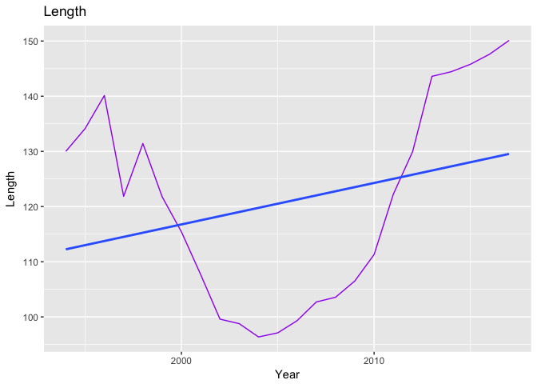

نمودار زمانی ضخامت:

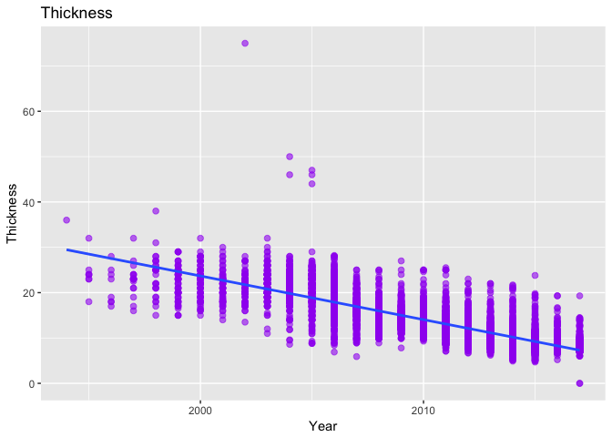

نمودار زمانی میانگین ضخامت:

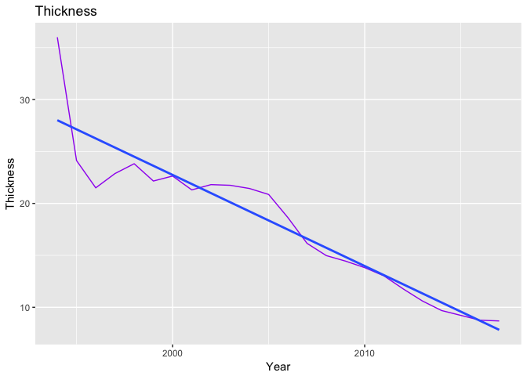

نمودار زمانی دوربین:

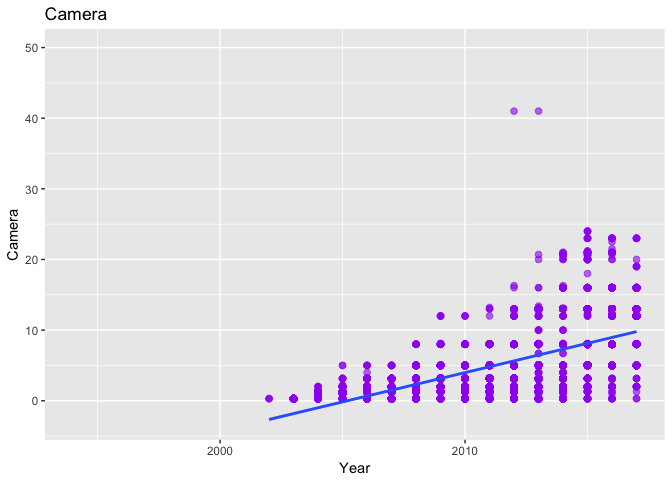

نمودار زمانی میانگین دوربین:

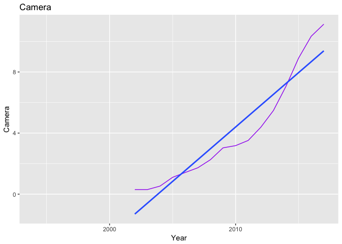

۳. نمودار ستونی متوسط قیمت گوشی بر حسب تعداد سیم کارت و دسترسی به LTE را رسم نمایید.

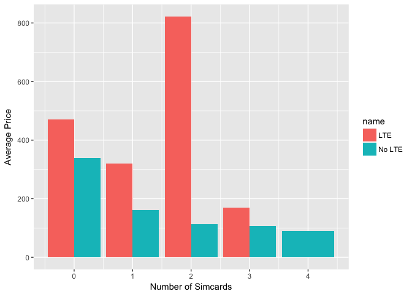

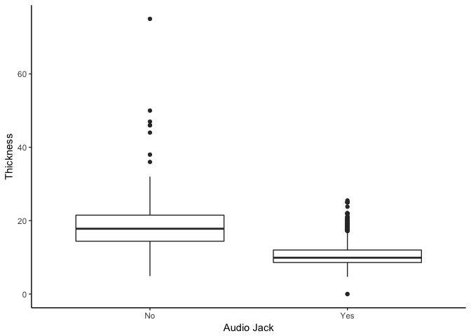

۵. مفهوم ppi را در گوشی های موبایل محاسبه و هیستوگرام آن را رسم نمایید. همچنین نمودار سالانه متوسط این کمیت را بکشید. کدام گوشی بیشترین ppi را دارد؟

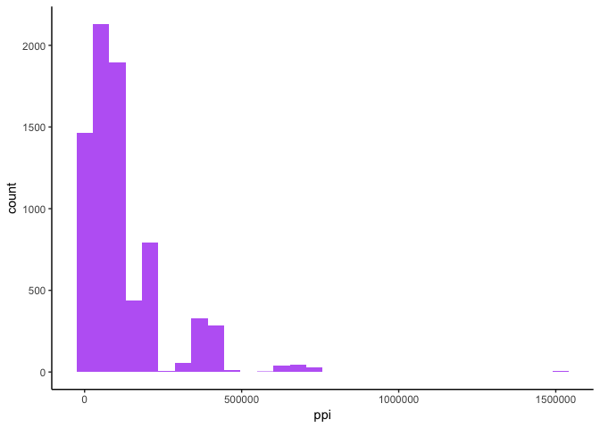

نمودار سالانه متوسط:

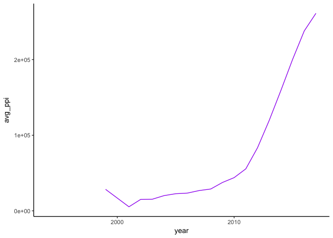

گوشی با بیشترین مقدار ppi:

```
## [1] "Sony"
```

```
## [1] "Xperia XZ Premium"
```

```
## [1] 1519121
```

۶. در گذشته به بعضی از مدل های گوشی نوکیا **گوشکوب** گفته می شد. سعی کنید برای این مفهوم کمیتی مناسب تعریف کنید . ده گوشکوب برتر را پیدا کرده و نمودار گوشکوبیت آن را رسم نمایید.

گوشکوب ها موبایل هایی هستند (تبلت ها گوشکوب نیستند) که علاوه بر این که معمولا ابعاد بزرگی دارند (طول و عرض)، بسیار ضخیم هم هستند. همچنین این گوشی ها معمولا قدیمی ترند و بسیار امکانات محدودی دارند. (دوربین ندارند یا اگر دارند با کیفیت پایین دارند قابلیت اتصال به اینترنت ندارند، درگاه مموری کارت ندارند، رادیو و هندزفری ندارند، جی پی اس ندارند و معمولا از یک سیم کارت بیشتر پشتیبانی نمیکنند.) در این سوال معیارهای بالا محاسبه شد و تبلت ها با محدودیت وزن و ابعاد از آن حذف شدند و در نهایت با ضریب دهی این معیارها امتیازی برای گوشکوبیت محاسبه شد. نمودار ۲۰ گوشکوب برتر و امتیاز آنها:

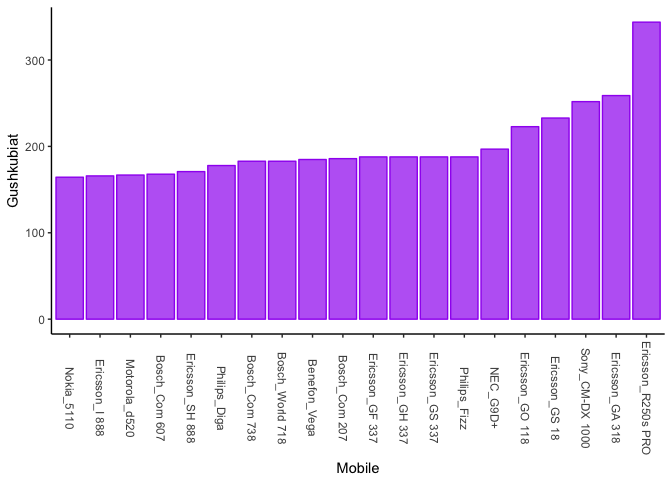

تصویر گوشکوب ترین گوشی طبق این امتیازها:

[figure not shown]

۷. آیا تلفن همراهی وجود دارد که در آب غرق نشود؟ اگر جواب بله هست تمام گوشی های که این خاصیت را دارند بیابید. با کشیدن یک نمودار به این سوال پاسخ دهید.

نمودار چگالی گوشی هایی که در آب غرق نمیشوند:

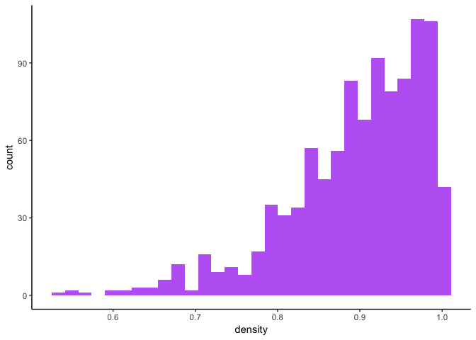

۸. نمودار پراکنش حجم ذخیره سازی باطری و وزن را رسم نمایید. میزان همبستگی بین این دو کمیت را محاسبه کنید.

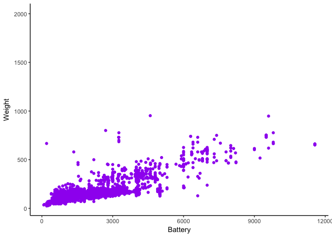

میزان همبستگی:

```
## [1] 0.8086273
```

۹. قیمت پرچمداران یک برند خاص مثلا سامسونگ را بیابید و نمودار قیمت زمان و نام مدل را رسم نمایید.

نمودار قیمت پرچمداران سامسونگ:

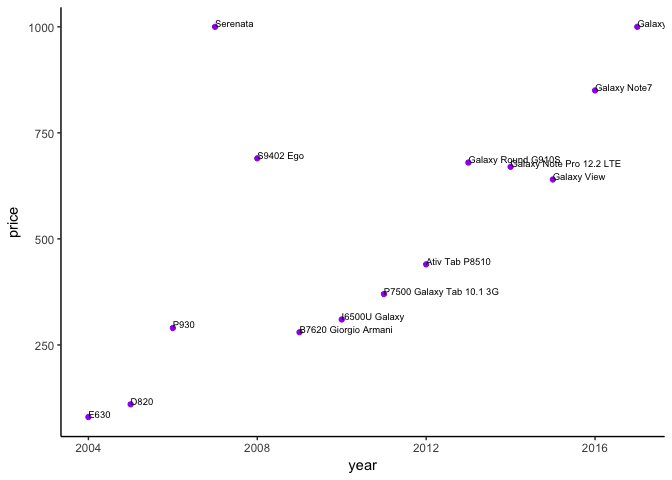

۱۰. سه نمودار جالب رسم کنید و توضیح دهید چرا از نظر شما جالب است؟

نمودار مقایسه میانگین قیمت شرکت های معروف در سال های مختلف. از این نظر جالب است که آیا یک شرکت همیشه گران تر از بقیه است یا نوسان هایی وجود دارد و در رقابت باهم شرکت ها قیمتهایشان را چطور تنظیم میکنند.

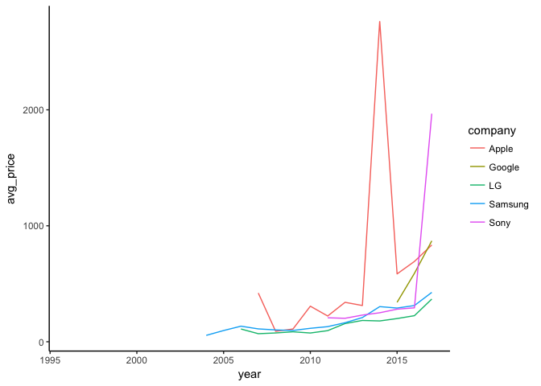

نمودار مقایسه میانگین کیفیت دوربین شرکت های معروف در سال های مختلف. آیا شرکتی وجود دارد که تمرکز خود را روی کیفیت دوربین موبایل های خود گذاشته باشد و تفاوت فاحشی در این زمینه با بقیه داشته باشد؟

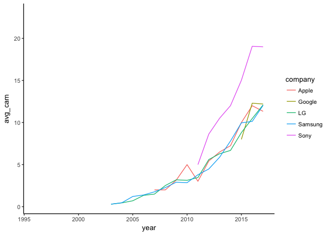

میخواهیم محاسبه کنیم کدام موبایل ها زودتر باتریشان تمام میشود. ظرفیت باتری یک پارامتر مهم است اما هرچه موبایل قابلیت های بیشتر و باکیفیت تری داشته باشد، این قابلیت ها شارژ بیشتری مصرف میکنند و باتری زودتر تمام میشود. این دلیلی است که موبایل های جدیدتر با اینکه نسبت به قدیمی تر ها باتری قوی تری دارند ولی شارژشان زودتر تمام میشود. در این جا با توجه به معیارهای بالا امتیازی برای هر موبایل محاسبه کردیم و میانگین این امتیاز را برای شرکت های معروف محاسبه کردیم. اپل بالاترین امتیاز را دارد که طبق گزارش ها هم چنین انتظاری داشتیم.

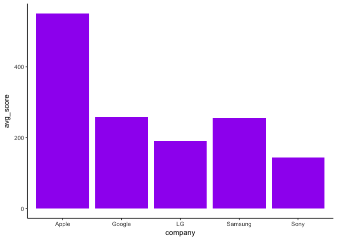